# 3D RNA-seq pipeline

Wenbin Guo

21 November 2018

## Load R package

Assume all the required R packages are installed.

```r
.libPaths('D:/R/win_library')
# library(ThreeDRNAseq)
## app.R ##
library(shiny)
library(shinydashboard)
library(rhandsontable)
library(shinyFiles)
library(tximport)
library(edgeR)
library(limma)
library(plotly)
library(RUVSeq)
library(eulerr)
library(gridExtra)
library(grid)
library(ComplexHeatmap)
library(Gmisc)
options(stringsAsFactors=F)

sourceDir <- function(path, trace = TRUE, ...) {
  for (nm in list.files(path, pattern = "[.][RrSsQq]$")) {
    #if(trace) cat(nm,":")
    source(file.path(path, nm), ...)
    #if(trace) cat("/n")
  }
}
sourceDir('D:/PhD project/R projects/test round 2018/ThreeDRNAseq/R')

################################################################################
### Set folder names to save results
##----->> save results to local folders
data.folder <- 'data' # for .RData format results
result.folder <- 'result' # for 3D analysis results in csv files
figure.folder <- 'figure' # for figures

### Set the input data folder
##----->> input data folder of samples.csv, mapping.csv, contrast.csv, etc.
input.folder <- 'examples/Arabidopsis_cold'
```

## Data generateion

Use the [tximport](http://bioconductor.org/packages/release/bioc/html/tximport.html) R package to generate the transcript and gene level read counts and TPMs (transcript per million reads).

```r
################################################################################
##----->> Sample information, e.g. conditions, bio-reps, seq-reps, abundance paths, etc.
samples <- read.csv(paste0(input.folder,'/samples.csv'))
samples$condition <- gsub(pattern = '_','.',samples$condition)
samples$sample.name <- paste0(samples$condition,'_',samples$brep,'_',samples$srep)
save(samples,file=paste0(data.folder,'/samples.RData'))
data.files <-  as.character(samples$path) #Complete path of abundance, e.g. quant.sf files of salmon.

##----->> Transcript-gene mapping
mapping <- read.csv(paste0(input.folder,'/mapping.csv'))
rownames(mapping) <- mapping$TXNAME
save(mapping,file=paste0(data.folder,'/mapping.RData'))

################################################################################
##----->> Generate gene expression
abundance.from <- 'salmon' # abundance generator
countsFromAbundance <- 'lengthScaledTPM' # method to generate expression in tximport
##
txi_genes <- tximport(data.files,dropInfReps = T,
                      type = abundance.from, tx2gene = mapping,
                      countsFromAbundance = countsFromAbundance)
```

```
## reading in files with read_tsv
```

```
## 1 2 3 4 5 6 7 8 9 10 11 12 13 14 15 16 17 18 19 20 21 22 23 24 25 26 27
## summarizing abundance
## summarizing counts
## summarizing length
```

```r
## give colunames to the datasets
colnames(txi_genes$counts)<- samples$sample.name
colnames(txi_genes$abundance)<-samples$sample.name
colnames(txi_genes$length)<-samples$sample.name

## save the data
write.csv(txi_genes$counts,file=paste0(result.folder,'/counts_genes.csv'))
write.csv(txi_genes$abundance,file=paste0(result.folder,'/TPM_genes.csv'))
save(txi_genes,file=paste0(data.folder,'/txi_genes.RData'))

################################################################################
##----->> Generate transcripts expression
txi_trans<- tximport(data.files, type = abundance.from, tx2gene = NULL,
                     countsFromAbundance = countsFromAbundance,
                     txOut = T,dropInfReps = T)
```

```
## reading in files with read_tsv
## 1 2 3 4 5 6 7 8 9 10 11 12 13 14 15 16 17 18 19 20 21 22 23 24 25 26 27
```

```r
## give colunames to the datasets
colnames(txi_trans$counts)<- samples$sample.name
colnames(txi_trans$abundance)<-samples$sample.name
colnames(txi_trans$length)<-samples$sample.name

## save the data
write.csv(txi_trans$counts,file=paste0(result.folder,'/counts_trans.csv'))
write.csv(txi_trans$abundance,file=paste0(result.folder,'/TPM_trans.csv'))
save(txi_trans,file=paste0(data.folder,'/txi_trans.RData'))

################################################################################
genes_counts=txi_genes$counts
trans_counts=txi_trans$counts
```

## Data pre-processing

### Step 1: Merge sequencing replicates

If the RNA-seq data includes sequencing replicates (i.e. the same biological replicate/library is sequenced multiple times), the sequencing replicates are merged to increase the library depths, since they do not provided useful information for biological/technical variability.

```r
##If no sequencing replicates, genes_counts and trans_counts remain the same by
##runing the command
idx <- paste0(samples$condition,'_',samples$brep)
genes_counts <- sumarrays(genes_counts,group = idx)
trans_counts <- sumarrays(trans_counts,group = idx)

## update the samples
samples_new <- samples[samples$srep==samples$srep[1],]
save(samples_new,file=paste0(data.folder,'/samples_new.RData'))
```

### Step 2: Filter low expression transcripts/genes

To filter the low expressed transcripts across the samples, the expression mean-variance trend is used to determine the CPM (count per million reads) cut-off for low expression and the number of samples to cut. A gene is expressed if any of its transcript is expressed. Please see the details in the 3D RNA-seq App user manual.

```r
################################################################################
##----->> Do the filters
cpm.cut <- 1
sample.n.cut <- 1
target_high <- counts.filter(counts = trans_counts,
                             mapping = mapping,
                             cpm.cut = cpm.cut,
                             sample.n = cpm.cut,
                             Log=F)
save(target_high,file=paste0(data.folder,'/target_high.RData'))

################################################################################
##----->> Mean-variance plot

## transcript level
condition <- paste0(samples_new$condition)
counts.raw = trans_counts[rowSums(trans_counts>0)>0,]
counts.filtered = trans_counts[target_high$trans_high,]
mv.trans <- check.mean.variance(counts.raw = counts.raw,
                                counts.filtered = counts.filtered,
                                condition = condition)
```

```
## => Generate DGEList object
```

```
## => Fit mean-variance trend
```

```
## Done!!!
```

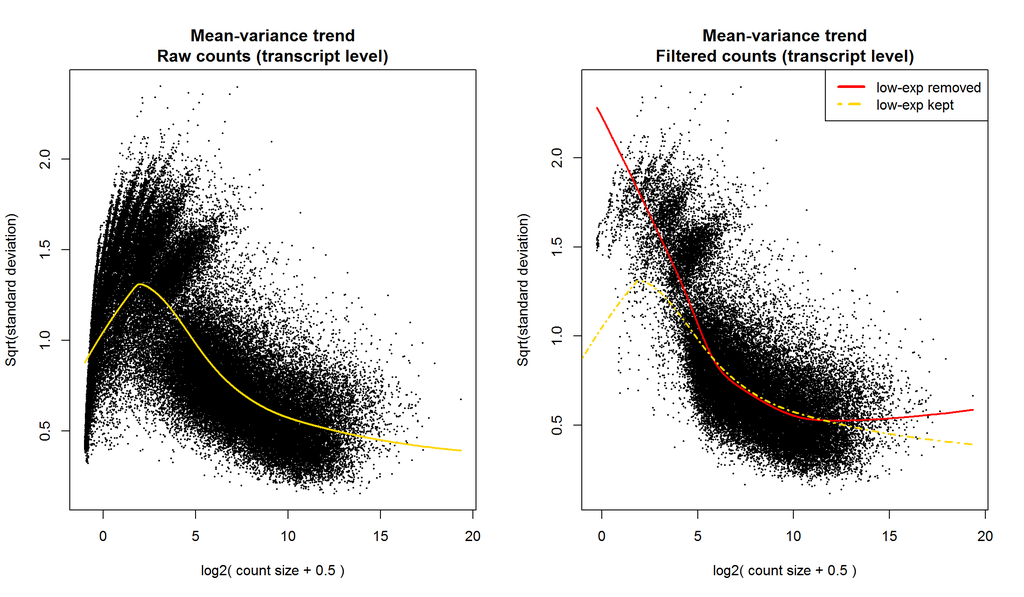

```r
### make plot
fit.raw <- mv.trans$fit.raw
fit.filtered <- mv.trans$fit.filtered
par(mfrow=c(1,2))
plot.mean.variance(x = fit.raw$sx,y = fit.raw$sy,
                   l = fit.raw$l,lwd=2,fit.line.col ='gold',col='black')
title('\n\nRaw counts (transcript level)')
plot.mean.variance(x = fit.filtered$sx,y = fit.filtered$sy,
                   l = fit.filtered$l,lwd=2,col='black')
title('\n\nFiltered counts (transcript level)')
lines(fit.raw$l, col = "gold",lty=4,lwd=2)
legend('topright',col = c('red','gold'),lty=c(1,4),lwd=3,
       legend = c('low-exp removed','low-exp kept'))
```

```r
################################################################################
## gene level
condition <- paste0(samples_new$condition)
counts.raw = genes_counts[rowSums(genes_counts>0)>0,]
counts.filtered = genes_counts[target_high$genes_high,]
mv.genes <- check.mean.variance(counts.raw = counts.raw,
                                counts.filtered = counts.filtered,
                                condition = condition)
```

```
## => Generate DGEList object
```

```
## => Fit mean-variance trend
```

```
## Done!!!
```

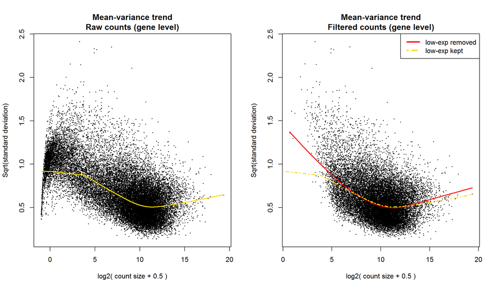

```r
### make plot
fit.raw <- mv.genes$fit.raw
fit.filtered <- mv.genes$fit.filtered
par(mfrow=c(1,2))
plot.mean.variance(x = fit.raw$sx,y = fit.raw$sy,
                   l = fit.raw$l,lwd=2,fit.line.col ='gold',col='black')
title('\n\nRaw counts (gene level)')
plot.mean.variance(x = fit.filtered$sx,y = fit.filtered$sy,
                   l = fit.filtered$l,lwd=2,col='black')
title('\n\nFiltered counts (gene level)')
lines(fit.raw$l, col = "gold",lty=4,lwd=2)
legend('topright',col = c('red','gold'),lty=c(1,4),lwd=3,
       legend = c('low-exp removed','low-exp kept'))
```

### Step 3: Principal component analysis (PCA)

The PCA plot is a rough visualization of expression variation across conditions/samples and to determine whether the data has batch effects between different biological replicates.

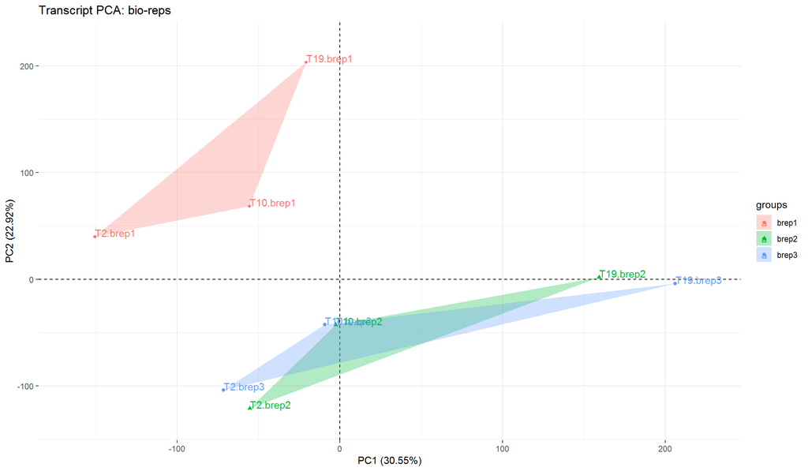

```r
################################################################################
##----->> trans level
data2pca <- trans_counts[target_high$trans_high,]
dge <- DGEList(counts=data2pca)
dge <- calcNormFactors(dge)
data2pca <- t(counts2CPM(obj = dge,Log = T))
dim1 <- 'PC1'
dim2 <- 'PC2'
ellipse.type <- 'polygon' #ellipse.type=c('none','ellipse','polygon')

##--All Bio-reps plots
rownames(data2pca) <- gsub('_','.',rownames(data2pca))
groups <- samples_new$brep ## colour on biological replicates
# groups <- samples_new$condition ## colour on condtions
g <- plot.PCA.ind(data2pca = data2pca,dim1 = dim1,dim2 = dim2,
                  groups = groups,plot.title = 'Transcript PCA: bio-reps',
                  ellipse.type = ellipse.type,
                  add.label = T,adj.label = F)

g
```

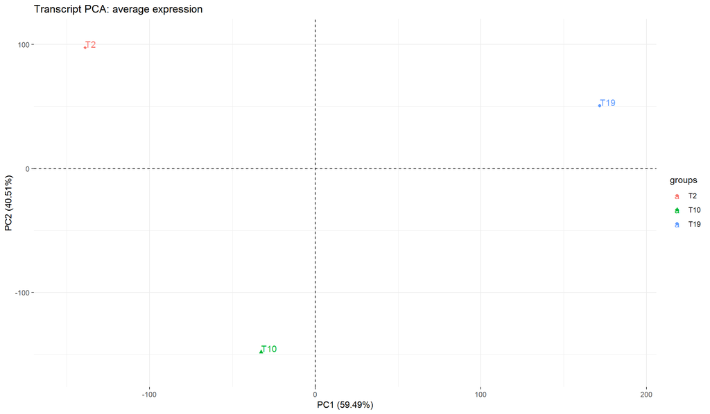

```r
##--average expression plot
rownames(data2pca) <- gsub('_','.',rownames(data2pca))
groups <- samples_new$brep
data2pca.ave <- rowmean(data2pca,samples_new$condition,reorder = F)
groups <- unique(samples_new$condition)
g <- plot.PCA.ind(data2pca = data2pca.ave,dim1 = 'PC1',dim2 = 'PC2',
                  groups = groups,plot.title = 'Transcript PCA: average expression',
                  ellipse.type = 'none',add.label = T,adj.label = F)

g
```

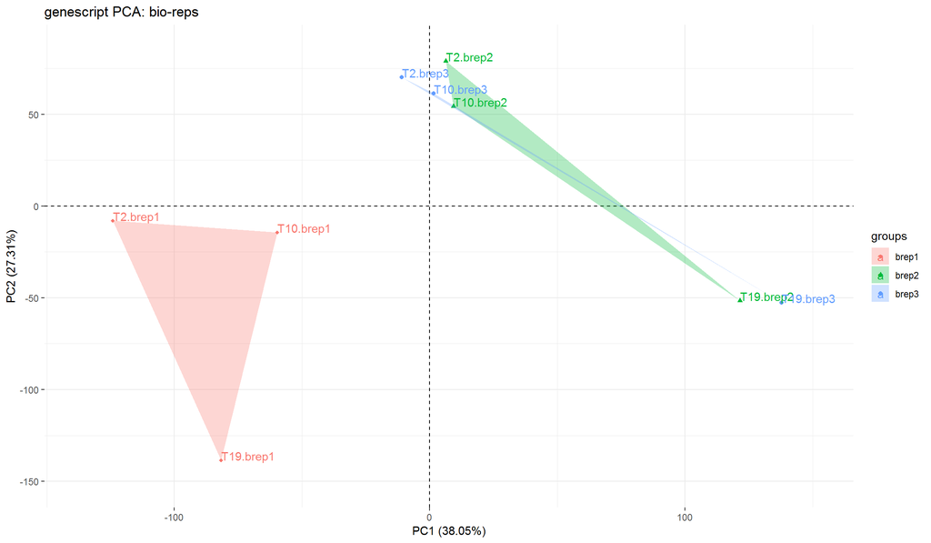

```r
################################################################################
##----->> genes level
data2pca <- genes_counts[target_high$genes_high,]
dge <- DGEList(counts=data2pca)
dge <- calcNormFactors(dge)
data2pca <- t(counts2CPM(obj = dge,Log = T))
dim1 <- 'PC1'
dim2 <- 'PC2'
ellipse.type <- 'polygon' #ellipse.type=c('none','ellipse','polygon')

##--All Bio-reps plots
rownames(data2pca) <- gsub('_','.',rownames(data2pca))
groups <- samples_new$brep ## colour on biological replicates
# groups <- samples_new$condition ## colour on condtions
g <- plot.PCA.ind(data2pca = data2pca,dim1 = dim1,dim2 = dim2,
                  groups = groups,plot.title = 'genescript PCA: bio-reps',
                  ellipse.type = ellipse.type,
                  add.label = T,adj.label = F)

g
```

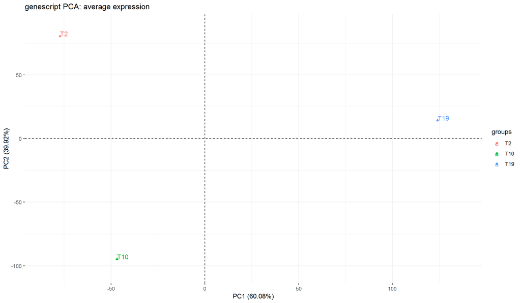

```r
##--average expression plot
rownames(data2pca) <- gsub('_','.',rownames(data2pca))
groups <- samples_new$brep
data2pca.ave <- rowmean(data2pca,samples_new$condition,reorder = F)
groups <- unique(samples_new$condition)
g <- plot.PCA.ind(data2pca = data2pca.ave,dim1 = 'PC1',dim2 = 'PC2',
                  groups = groups,plot.title = 'genescript PCA: average expression',
                  ellipse.type = 'none',add.label = T,adj.label = F)

g
```

### Step 3-continued: Batch effect estimation

Only if see clear batch effects on the PCA plots, otherwise skip this step. The [RUVSeq](https://bioconductor.org/packages/release/bioc/html/RUVSeq.html) is used to estimate the batch effects. It will generate modified read counts, where the batch effects have been removed, for batch-free PCA plots and batch effect term which can be passed to the linear regression model for 3D analysis.

```r
ruvseq.method <- 'RUVr' # ruvseq.method is one of 'RUVr', 'RUVs' and 'RUVg'
design <- condition2design(condition = samples_new$condition,
                           batch.effect = NULL)


################################################################################
##----->> trans level
trans_batch <- remove.batch(read.counts = trans_counts[target_high$trans_high,],
                            condition = samples_new$condition,
                            design = design,
                            contrast=NULL,
                            group = samples_new$condition,
                            method = ruvseq.method)
```

```
## Estimate norm factor...
```

```
## Estimate Common Dispersion for Negative Binomial GLMs ...
```

```
## Fit genewise Negative Binomial Generalized Linear Models and calculate residuals...
```

```
## Remove Unwanted Variation Using RUVr...
```

```
## Time for analysis: 18.5 secs
```

```
## Done!!!
```

```r
save(trans_batch,file=paste0(data.folder,'/trans_batch.RData'))

################################################################################
##----->> genes level
genes_batch <- remove.batch(read.counts = genes_counts[target_high$genes_high,],
                            condition = samples_new$condition,
                            design = design,
                            contrast=NULL,
                            group = samples_new$condition,
                            method = ruvseq.method)
```

```
## Estimate norm factor...
```

```
## Estimate Common Dispersion for Negative Binomial GLMs ...
```

```
## Fit genewise Negative Binomial Generalized Linear Models and calculate residuals...
```

```
## Remove Unwanted Variation Using RUVr...
```

```
## Time for analysis: 10.108 secs
```

```
## Done!!!
```

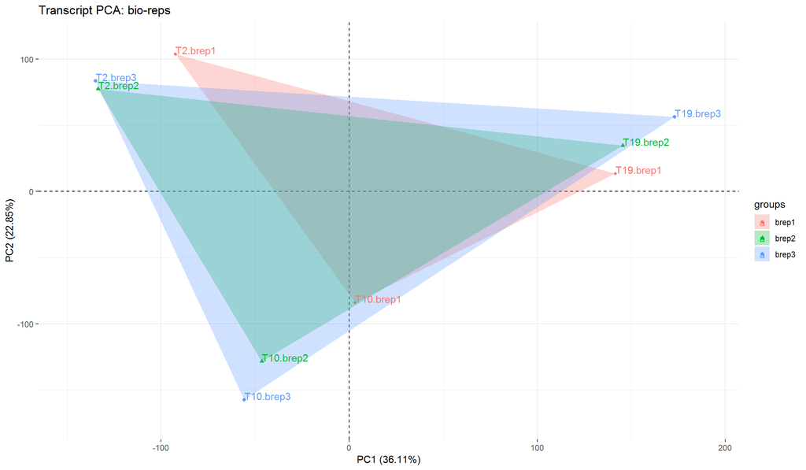

```r
save(genes_batch,file=paste0(data.folder,'/genes_batch.RData'))


################################################################################
## DO the PCA again
################################################################################

##----->> trans level
data2pca <- trans_batch$normalizedCounts[target_high$trans_high,]
dge <- DGEList(counts=data2pca)
dge <- calcNormFactors(dge)
data2pca <- t(counts2CPM(obj = dge,Log = T))
dim1 <- 'PC1'
dim2 <- 'PC2'
ellipse.type <- 'polygon' #ellipse.type=c('none','ellipse','polygon')

##--All Bio-reps plots
rownames(data2pca) <- gsub('_','.',rownames(data2pca))
groups <- samples_new$brep ## colour on biological replicates
# groups <- samples_new$condition ## colour on condtions
g <- plot.PCA.ind(data2pca = data2pca,dim1 = dim1,dim2 = dim2,
                  groups = groups,plot.title = 'Transcript PCA: bio-reps',
                  ellipse.type = ellipse.type,
                  add.label = T,adj.label = F)

g
```

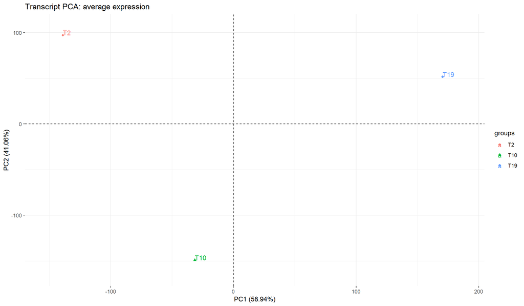

```r
##--average expression plot
rownames(data2pca) <- gsub('_','.',rownames(data2pca))
groups <- samples_new$brep
data2pca.ave <- rowmean(data2pca,samples_new$condition,reorder = F)
groups <- unique(samples_new$condition)
g <- plot.PCA.ind(data2pca = data2pca.ave,dim1 = 'PC1',dim2 = 'PC2',
                  groups = groups,plot.title = 'Transcript PCA: average expression',
                  ellipse.type = 'none',add.label = T,adj.label = F)

g
```

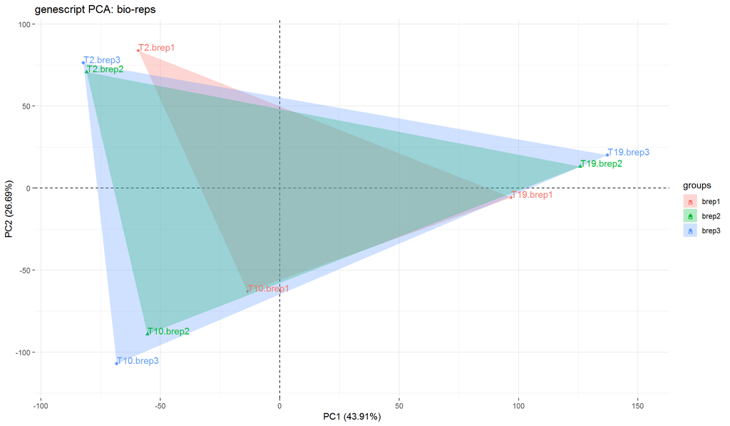

```r
################################################################################
##----->> genes level
data2pca <- genes_batch$normalizedCounts[target_high$genes_high,]
dge <- DGEList(counts=data2pca)
dge <- calcNormFactors(dge)
data2pca <- t(counts2CPM(obj = dge,Log = T))
dim1 <- 'PC1'
dim2 <- 'PC2'
ellipse.type <- 'polygon' #ellipse.type=c('none','ellipse','polygon')

##--All Bio-reps plots
rownames(data2pca) <- gsub('_','.',rownames(data2pca))
groups <- samples_new$brep ## colour on biological replicates
# groups <- samples_new$condition ## colour on condtions
g <- plot.PCA.ind(data2pca = data2pca,dim1 = dim1,dim2 = dim2,
                  groups = groups,plot.title = 'genescript PCA: bio-reps',
                  ellipse.type = ellipse.type,
                  add.label = T,adj.label = F)

g
```

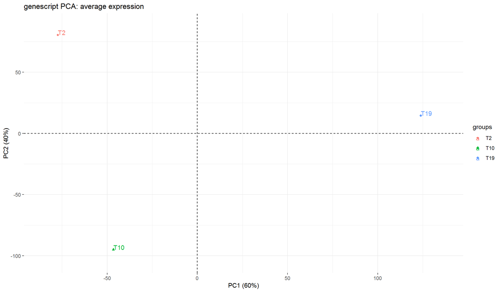

```r
##--average expression plot
rownames(data2pca) <- gsub('_','.',rownames(data2pca))
groups <- samples_new$brep
data2pca.ave <- rowmean(data2pca,samples_new$condition,reorder = F)
groups <- unique(samples_new$condition)
g <- plot.PCA.ind(data2pca = data2pca.ave,dim1 = 'PC1',dim2 = 'PC2',
                  groups = groups,plot.title = 'genescript PCA: average expression',
                  ellipse.type = 'none',add.label = T,adj.label = F)

g
```

### Step 4: Data normalisation

The same transcript/gene in deeplier sequenced samples have more mapped reads. To make genes/transcripts comparable across samples, the “TMM”, “RLE” or “upperquantile” method can be used to normalize the expression.

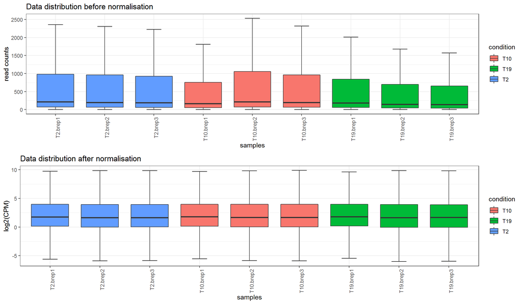

```r
################################################################################
##----->> trans level
norm.method <- 'TMM' ## norm.method is one of 'TMM','RLE' and 'upperquartile'
dge <- DGEList(counts=trans_counts[target_high$trans_high,],
               group = samples_new$condition,
               genes = mapping[target_high$trans_high,])
trans_dge <- suppressWarnings(calcNormFactors(dge,method = norm.method))
save(trans_dge,file=paste0(data.folder,'/trans_dge.RData'))

################################################################################
##----->> genes level
dge <- DGEList(counts=genes_counts[target_high$genes_high,],
               group = samples_new$condition)
genes_dge <- suppressWarnings(calcNormFactors(dge,method = norm.method))
save(genes_dge,file=paste0(data.folder,'/genes_dge.RData'))

################################################################################
##----->> distribution plot
sample.name <- paste0(samples_new$condition,'.',samples_new$brep)
condition <- samples_new$condition

###--- trans level
data.before <- trans_counts[target_high$trans_high,]
data.after <- counts2CPM(obj = trans_dge,Log = T)
g <- boxplot.normalised(data.before = data.before,
                        data.after = data.after,
                        condition = condition,
                        sample.name = sample.name)
do.call(grid.arrange,g)
```

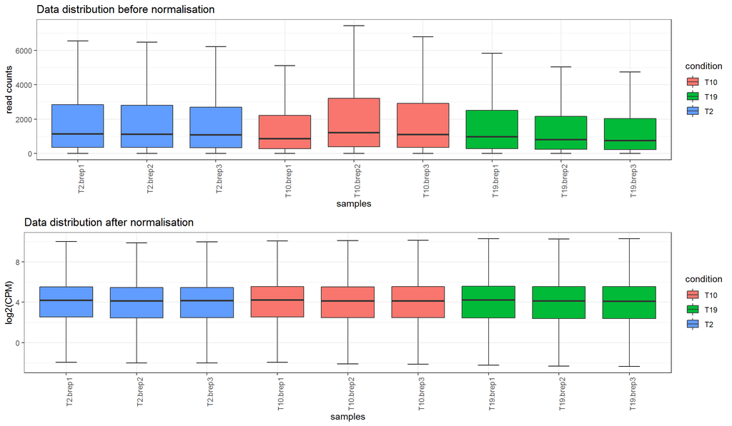

```r
###--- genes level
data.before <- genes_counts[target_high$genes_high,]
data.after <- counts2CPM(obj = genes_dge,Log = T)
g <- boxplot.normalised(data.before = data.before,
                        data.after = data.after,
                        condition = condition,
                        sample.name = sample.name)
do.call(grid.arrange,g)
```

## DE, DAS and DTU analysis

Three pipelines, [limma](https://bioconductor.org/packages/release/bioc/html/limma.html), [glmQL (edgeR)](https://bioconductor.org/packages/release/bioc/html/edgeR.html) and [glm (edgeR)](https://bioconductor.org/packages/release/bioc/html/edgeR.html) are provided for DE gene and transcripts analysis. “limma” and “edgeR” have comparable performance and they have stringent controls of false positives than the “glm”.

### Step 1: Load contrast group

```r
# The contrast groups passed to the analysis are in a vector object, e.g. \code{contrast <- c('B-A','C-A')} means compare conditions "B" and "C" to condition "A".
contrast <- read.csv(paste0(input.folder,'/contrast.csv'))
contrast <- paste0(contrast[,1],'-',contrast[,2])
###---generate proper contrast format
contrast <- gsub('_','.',contrast)
```

### Step 2: DE genes

```r
batch.effect <- genes_batch$W
# batch.effect <- NULL ## if has no batch effects
design <- condition2design(condition = samples_new$condition,
                           batch.effect = batch.effect)

################################################################################
p.adjust.method <- 'BH'
pval.cutoff <- 0.01
lfc.cutoff <- 1
##----->> limma pipeline
genes_3D_stat <- limma.pipeline(dge = genes_dge,
                                 design = design,
                                 deltaPS = NULL,
                                 contrast = contrast,
                                 diffAS = F,
                                 adjust.method = p.adjust.method)
```

```
## Limma-voon to estimate mean-vriance trend ...
```

```
## Fit a basic linear model ...
```

```
## Fit the contrast model ...
```

```
## [1] "Contrast groups: T10-T2; T19-T2"
```

```
## Fit a eBayes model ...
```

```
## Testing for each contrast group ...
```

```
## Testing across all contrast groups ...
```

```
## Time for analysis: 1.915
```

```
## Done!!!
```

```r
##----->> edgeR glmQL pipeline
# genes_3D_stat <- edgeR.pipeline(dge = genes_dge,
#                                  design = design,
#                                  deltaPS = NULL,
#                                  contrast = contrast,
#                                  diffAS = F,
#                                  method = 'glmQL',
#                                  adjust.method = p.adjust.method)

##----->> edgeR glm pipeline
# genes_3D_stat <- edgeR.pipeline(dge = genes_dge,
#                                  design = design,
#                                  deltaPS = NULL,
#                                  contrast = contrast,
#                                  diffAS = F,
#                                  method = 'glm',
#                                  adjust.method = p.adjust.method)

## save results
save(genes_3D_stat,file=paste0(data.folder,'/genes_3D_stat.RData'))
```

### Step 3: DAS genes, DE and DTU transcripts

```r
################################################################################
##----->> generate deltaPS
transAbundance <- txi_trans$abundance[target_high$trans_high,]
deltaPS <- transAbundance2PS(transAbundance = transAbundance,
                             PS = NULL,
                             contrast = contrast,
                             condition = samples$condition,
                             mapping = mapping[target_high$trans_high,])
PS <- deltaPS$PS
deltaPS <- deltaPS$deltaPS
## save
save(deltaPS,file=paste0(data.folder,'/deltaPS.RData'))
save(PS,file=paste0(data.folder,'/PS.RData'))

################################################################################
##----->> DAS genes,DE and DTU transcripts
batch.effect <- genes_batch$W
# batch.effect <- NULL ## if has no batch effects
design <- condition2design(condition = samples_new$condition,
                           batch.effect = batch.effect)

################################################################################
p.adjust.method <- 'BH'
pval.cutoff <- 0.01
lfc.cutoff <- 1
deltaPS.cutoff <- 0.1
##----->> limma pipeline
trans_3D_stat <- limma.pipeline(dge = trans_dge,
                                 design = design,
                                 deltaPS = deltaPS,
                                 contrast = contrast,
                                 diffAS = T,
                                 adjust.method = p.adjust.method)
```

```
## Limma-voon to estimate mean-vriance trend ...
```

```
## Fit a basic linear model ...
```

```
## Fit the contrast model ...
```

```
## [1] "Contrast groups: T10-T2; T19-T2"
```

```
## Fit a eBayes model ...
```

```
## Testing for each contrast group ...
```

```
## Testing across all contrast groups ...
```

```
## Fit a splicing model ...
```

```
## Total number of exons:  41871
## Total number of genes:  19594
## Number of genes with 1 exon:  10233
## Mean number of exons in a gene:  2
## Max number of exons in a gene:  31
```

```
## Time for analysis: 6.598
```

```
## Done!!!
```

```r
##----->> edgeR glmQL pipeline
# trans_3D_stat <- edgeR.pipeline(dge = trans_dge,
#                                  design = design,
#                                  deltaPS = deltaPS,
#                                  contrast = contrast,
#                                  diffAS = T,
#                                  method = 'glmQL',
#                                  adjust.method = p.adjust.method)

##----->> edgeR glm pipeline
# trans_3D_stat <- edgeR.pipeline(dge = trans_dge,
#                                  design = design,
#                                  deltaPS = deltaPS,
#                                  contrast = contrast,
#                                  diffAS = T,
#                                  method = 'glm',
#                                  adjust.method = p.adjust.method)

## save results
save(trans_3D_stat,file=paste0(data.folder,'/trans_3D_stat.RData'))
```

## Result summary

### Significant 3D targets and testing statistics

```r
################################################################################
##----->> Summary DE genes
DE_genes <- summary.DE.target(stat = genes_3D_stat$DE.stat,
                              cutoff = c(adj.pval=pval.cutoff,
                                         log2FC=lfc.cutoff))

################################################################################
## summary DAS genes, DE and DTU trans
##----->> DE trans
DE_trans <- summary.DE.target(stat = trans_3D_stat$DE.stat,
                              cutoff = c(adj.pval=pval.cutoff,
                                         log2FC=lfc.cutoff))

##----->> DAS genes
DAS.p.method <- 'F-test' ## DAS.p.method is one of 'F-test' and
if(DAS.p.method=='F-test') {
  DAS.stat <- trans_3D_stat$DAS.F.stat
} else {
  DAS.stat <- trans_3D_stat$DAS.Simes.stat
}

lfc <- genes_3D_stat$DE.lfc
lfc <- reshape2::melt(as.matrix(lfc))
colnames(lfc) <- c('target','contrast','log2FC')
DAS_genes <- summary.DAS.target(stat = DAS.stat,
                                lfc = lfc,
                                cutoff=c(pval.cutoff,deltaPS.cutoff))

##----->> DTU trans
lfc <- trans_3D_stat$DE.lfc
lfc <- reshape2::melt(as.matrix(lfc))
colnames(lfc) <- c('target','contrast','log2FC')
DTU_trans <- summary.DAS.target(stat = trans_3D_stat$DTU.stat,
                                lfc = lfc,cutoff = c(adj.pval=pval.cutoff,
                                                     deltaPS=deltaPS.cutoff))

################################################################################
## save results
save(DE_genes,file=paste0(data.folder,'/DE_genes.RData'))
save(DE_trans,file=paste0(data.folder,'/DE_trans.RData'))
save(DAS_genes,file=paste0(data.folder,'/DAS_genes.RData'))
save(DTU_trans,file=paste0(data.folder,'/DTU_trans.RData'))

## csv
write.csv(DE_genes,file=paste0(result.folder,'/DE genes.csv'),row.names = F)
write.csv(DAS_genes,file=paste0(result.folder,'/DAS genes.csv'),row.names = F)
write.csv(DE_trans,file=paste0(result.folder,'/DE transcripts.csv'),row.names = F)
write.csv(DTU_trans,file=paste0(result.folder,'/DTU transcripts.csv'),row.names = F)
```

### Significant 3D target numbers

```r
################################################################################
##----->> target numbers
summary.3D.number(DE_genes = DE_genes,
                  DAS_genes = DAS_genes,
                  DE_trans = DE_trans,
                  DTU_trans=DTU_trans,
                  contrast = contrast)
```

```
##       contrast DE genes DAS genes DE transcripts DTU transcripts
## 1       T10-T2      946       362           1271             598
## 2       T19-T2     2261       883           3079            1479
## 3 Intersection      433       244            599             377
```

```r
################################################################################
##----->> DE vs DAS
DEvsDAS.results <- DEvsDAS(DE_genes = DE_genes,
                           DAS_genes = DAS_genes,
                           contrast = contrast)

################################################################################
##----->> DE vs DTU
DEvsDTU.results <- DEvsDTU(DE_trans = DE_trans,
                           DTU_trans = DTU_trans,
                           contrast = contrast)
```

### Make plot

#### Up- and down-regulation

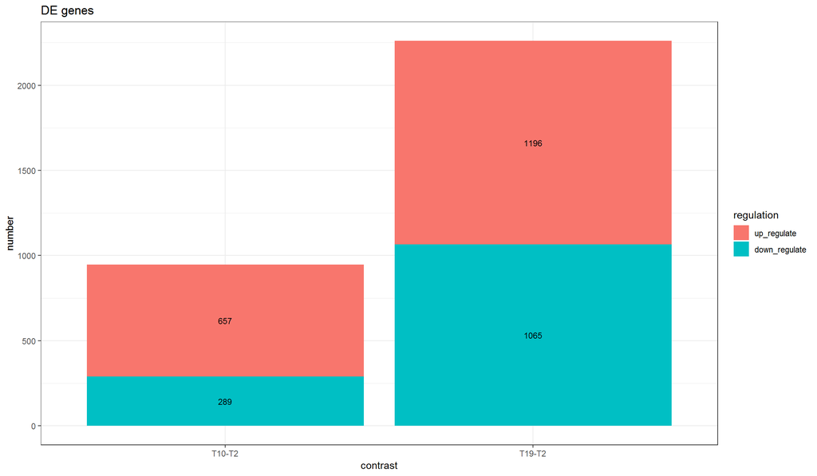

```r
################################################################################
##----->> DE genes
idx <- factor(DE_genes$contrast,levels = contrast)
targets <-  split(DE_genes,idx)
data2plot <- lapply(contrast,function(i){
  if(nrow(targets[[i]])==0){
    x <- data.frame(contrast=i,regulation=c('down_regulate','up_regulate'),number=0)
  } else {
    x <- data.frame(contrast=i,table(targets[[i]]$up.down))
    colnames(x) <- c('contrast','regulation','number')
  }
  x
})
data2plot <- do.call(rbind,data2plot)
plot.updown(data2plot,plot.title = 'DE genes',contrast = contrast)
```

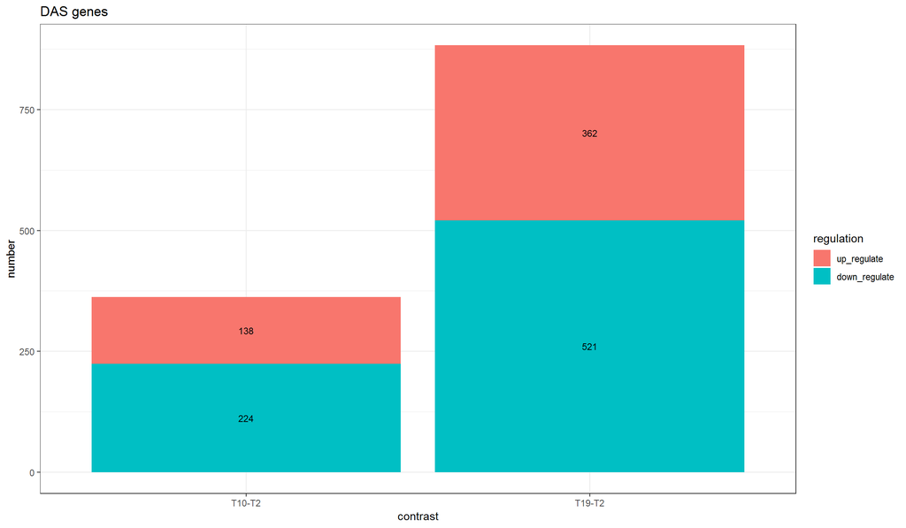

```r
################################################################################
##----->> DAS genes
idx <- factor(DAS_genes$contrast,levels = contrast)
targets <-  split(DAS_genes,idx)
data2plot <- lapply(contrast,function(i){
  if(nrow(targets[[i]])==0){
    x <- data.frame(contrast=i,regulation=c('down_regulate','up_regulate'),number=0)
  } else {
    x <- data.frame(contrast=i,table(targets[[i]]$up.down))
    colnames(x) <- c('contrast','regulation','number')
  }
  x
})
data2plot <- do.call(rbind,data2plot)
plot.updown(data2plot,plot.title = 'DAS genes',contrast = contrast)
```

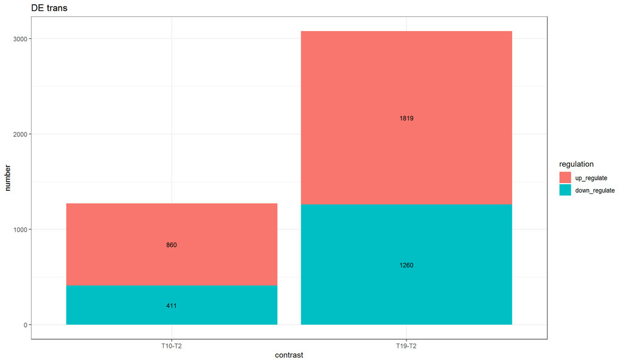

```r
################################################################################
##----->> DE trans
idx <- factor(DE_trans$contrast,levels = contrast)
targets <-  split(DE_trans,idx)
data2plot <- lapply(contrast,function(i){
  if(nrow(targets[[i]])==0){
    x <- data.frame(contrast=i,regulation=c('down_regulate','up_regulate'),number=0)
  } else {
    x <- data.frame(contrast=i,table(targets[[i]]$up.down))
    colnames(x) <- c('contrast','regulation','number')
  }
  x
})
data2plot <- do.call(rbind,data2plot)
plot.updown(data2plot,plot.title = 'DE trans',contrast = contrast)
```

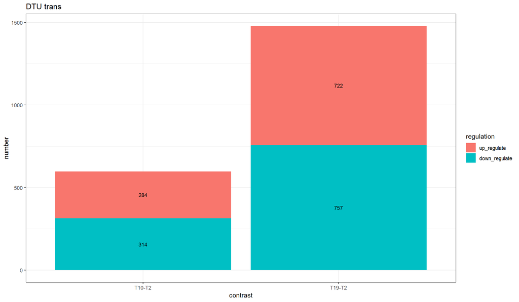

```r
################################################################################
##----->> DTU trans
idx <- factor(DTU_trans$contrast,levels = contrast)
targets <-  split(DTU_trans,idx)
data2plot <- lapply(contrast,function(i){
  if(nrow(targets[[i]])==0){
    x <- data.frame(contrast=i,regulation=c('down_regulate','up_regulate'),number=0)
  } else {
    x <- data.frame(contrast=i,table(targets[[i]]$up.down))
    colnames(x) <- c('contrast','regulation','number')
  }
  x
})
data2plot <- do.call(rbind,data2plot)
plot.updown(data2plot,plot.title = 'DTU trans',contrast = contrast)
```

#### Flow chart

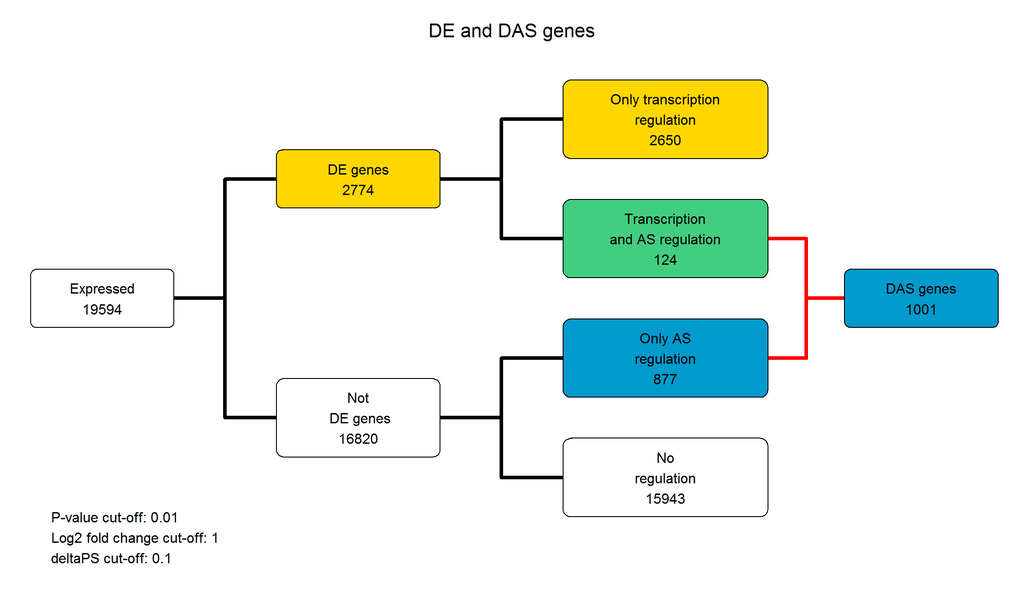

```r
################################################################################
##----->> DE vs DAS genes
DE.genes <- unique(DE_genes$target)
DAS.genes <- unique(DAS_genes$target)
plot.flow.chart(expressed = target_high$genes_high,
                x = DE.genes,
                y = DAS.genes,
                type = 'genes',
                pval.cutoff = pval.cutoff,
                lfc.cutoff = lfc.cutoff,
                deltaPS.cutoff = deltaPS.cutoff)
```

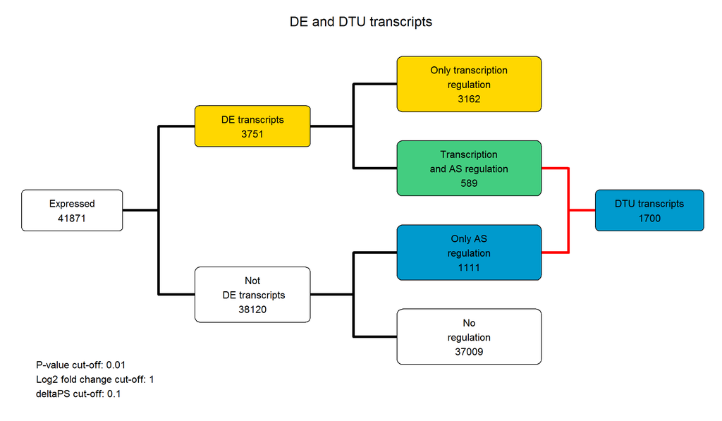

```r
################################################################################
##----->> DE vs DTU transcripts
DE.trans<- unique(DE_trans$target)
DTU.trans <- unique(DTU_trans$target)

plot.flow.chart(expressed = target_high$trans_high,
                x = DE.trans,
                y = DTU.trans,
                type = 'transcripts',
                pval.cutoff = pval.cutoff,
                lfc.cutoff = lfc.cutoff,
                deltaPS.cutoff = deltaPS.cutoff)
```

#### Comparisons between contrast groups

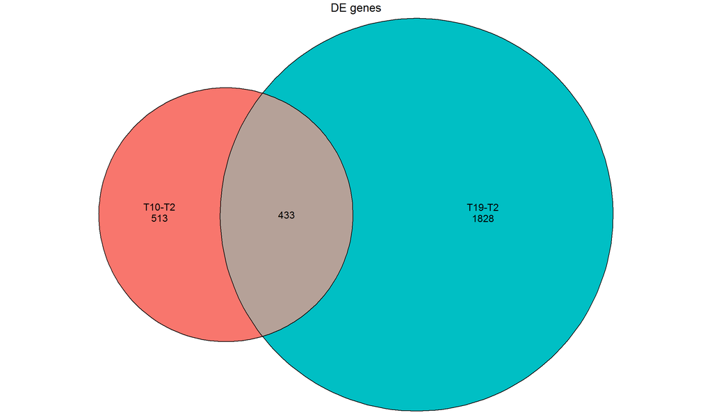

```r
################################################################################
##----->> DE genes
targets <- lapply(contrast,function(i){
  subset(DE_genes,contrast==i)$target
})
names(targets) <- contrast
g <- plot.euler.diagram(x = targets)
grid.arrange(g,top=textGrob('DE genes', gp=gpar(cex=1.2)))
```

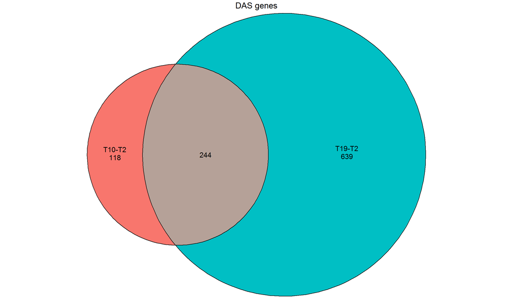

```r
################################################################################
##----->> DAS genes
targets <- lapply(contrast,function(i){
  subset(DAS_genes,contrast==i)$target
})
names(targets) <- contrast
g <- plot.euler.diagram(x = targets)
grid.arrange(g,top=textGrob('DAS genes', gp=gpar(cex=1.2)))
```

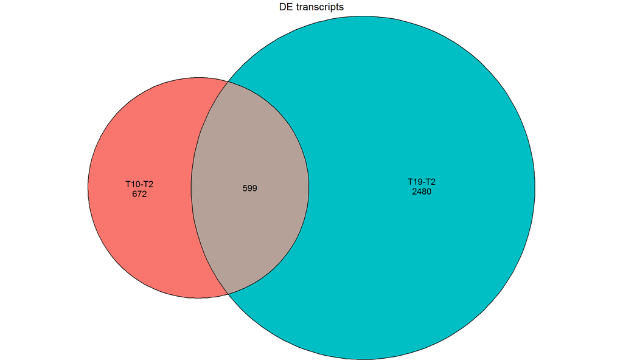

```r
################################################################################
##----->> DE transcripts
targets <- lapply(contrast,function(i){
  subset(DE_trans,contrast==i)$target
})
names(targets) <- contrast
g <- plot.euler.diagram(x = targets)
grid.arrange(g,top=textGrob('DE transcripts', gp=gpar(cex=1.2)))
```

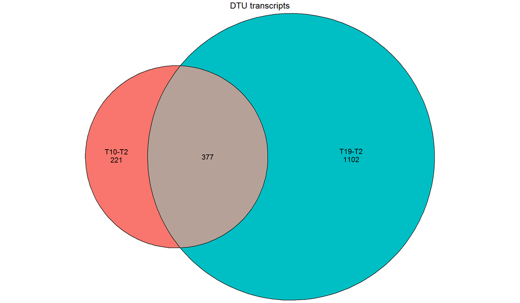

```r
################################################################################
##----->> DTU transcripts
targets <- lapply(contrast,function(i){
  subset(DTU_trans,contrast==i)$target
})
names(targets) <- contrast
g <- plot.euler.diagram(x = targets)
grid.arrange(g,top=textGrob('DTU transcripts', gp=gpar(cex=1.2)))
```

#### Comparison of transcription and AS targets

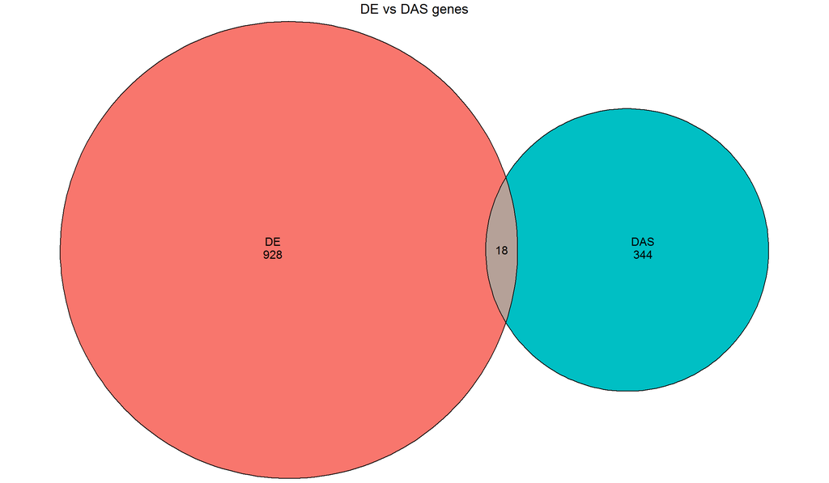

```r
contrast.idx <- contrast[1]
################################################################################
##----->> DE vs DAS genes
x <- unlist(DEvsDAS.results[DEvsDAS.results$Contrast==contrast.idx,-1])
if(length(x)==0){
  message('No DE and/or DAS genes')
} else {
  names(x) <- c('DE','DE&DAS','DAS')
  g <- plot.euler.diagram(x = x,fill = gg.color.hue(2))
  g
  grid.arrange(g,top=textGrob('DE vs DAS genes', gp=gpar(cex=1.2)))
}
```

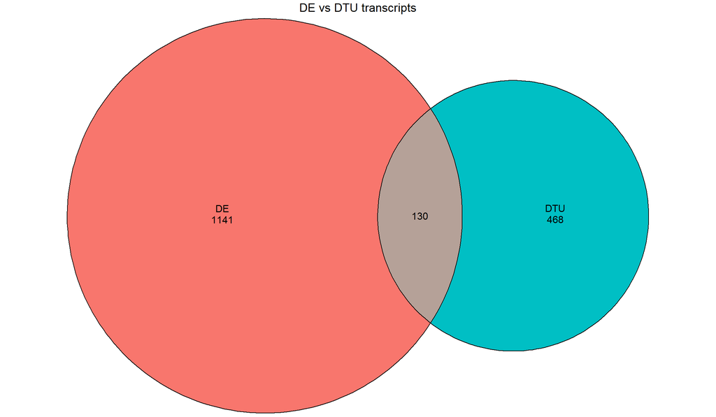

```r
################################################################################
##----->> DE vs DTU transcripts
x <- unlist(DEvsDTU.results[DEvsDTU.results$Contrast==contrast.idx,-1])
if(length(x)==0){
  message('No DE and/or DTU transcripts')
} else {
  names(x) <- c('DE','DE&DTU','DTU')
  g <- plot.euler.diagram(x = x,fill = gg.color.hue(2))
  g
  grid.arrange(g,top=textGrob('DE vs DTU transcripts', gp=gpar(cex=1.2)))
}
```

## Advanced plots

### Heatmap of 3D targets

The targets are firstly clustered into groups by using the [fastcluster](https://cran.r-project.org/web/packages/fastcluster/index.html) R package, and then made into heatmap by using the [ComplexHeatmap](https://bioconductor.org/packages/release/bioc/html/ComplexHeatmap.html) R package

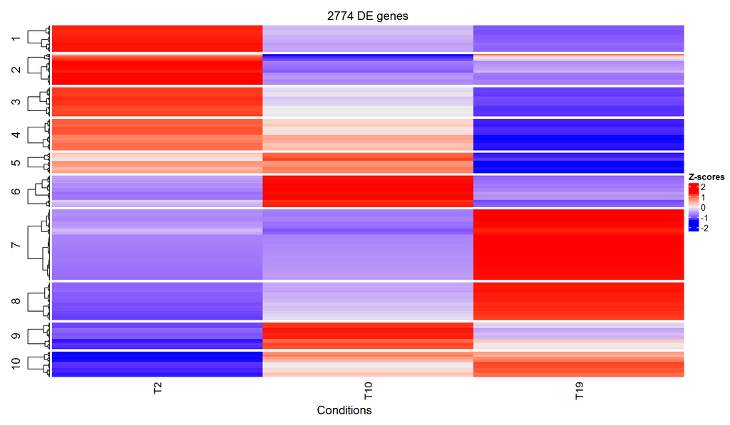

```r
################################################################################
##----->> DE genes
dist.method <- 'euclidean'
cluster.method <- 'ward.D'
cluster.number <- 10
targets <- unique(DE_genes$target)
data2heatmap <- txi_genes$abundance[targets,]
column_title <- paste0(length(targets),' DE genes')
data2plot <- rowmean(x = t(data2heatmap),
                     group = samples$condition,
                     reorder = F)
data2plot <- t(scale(data2plot))

hc.dist <- dist(data2plot,method = dist.method)
hc <- fastcluster::hclust(hc.dist,method = cluster.method)
clusters <- cutree(hc, k = cluster.number)
clusters <- reorder.clusters(clusters = clusters,dat = data2plot)

g <- Heatmap(as.matrix(data2plot), name = 'Z-scores',
             cluster_rows = TRUE,
             clustering_method_rows=cluster.method,
             row_dend_reorder = T,
             show_row_names = FALSE,
             show_column_names = ifelse(ncol(data2plot)>10,F,T),
             cluster_columns = FALSE,
             split=clusters,
             column_title= column_title)

draw(g,column_title='Conditions',column_title_side = "bottom")
```

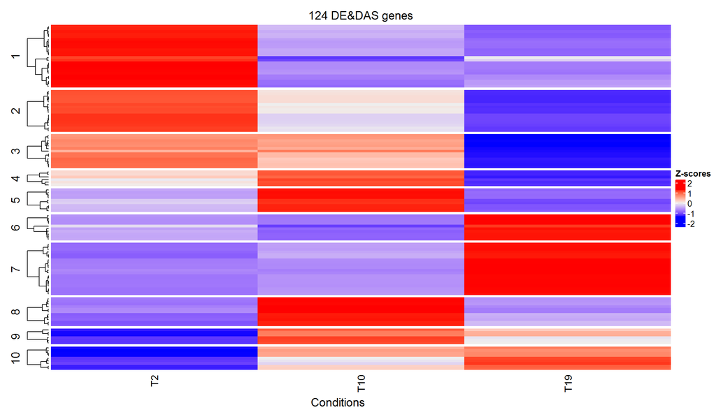

```r
################################################################################
##----->> DAS genes
dist.method <- 'euclidean'
cluster.method <- 'ward.D'
cluster.number <- 10
targets <- intersect(unique(DE_genes$target),unique(DAS_genes$target))
data2heatmap <- txi_genes$abundance[targets,]
column_title <- paste0(length(targets),' DE&DAS genes')
data2plot <- rowmean(x = t(data2heatmap),
                     group = samples$condition,
                     reorder = F)
data2plot <- t(scale(data2plot))

hc.dist <- dist(data2plot,method = dist.method)
hc <- fastcluster::hclust(hc.dist,method = cluster.method)
clusters <- cutree(hc, k = cluster.number)
clusters <- reorder.clusters(clusters = clusters,dat = data2plot)

g <- Heatmap(as.matrix(data2plot), name = 'Z-scores',
             cluster_rows = TRUE,
             clustering_method_rows=cluster.method,
             row_dend_reorder = T,
             show_row_names = FALSE,
             show_column_names = ifelse(ncol(data2plot)>10,F,T),
             cluster_columns = FALSE,
             split=clusters,
             column_title= column_title)

draw(g,column_title='Conditions',column_title_side = "bottom")
```

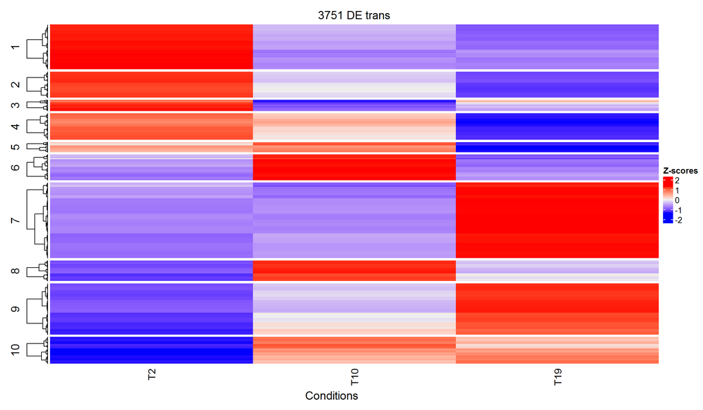

```r
################################################################################
##----->> DE trans
dist.method <- 'euclidean'
cluster.method <- 'ward.D'
cluster.number <- 10
targets <- unique(DE_trans$target)
data2heatmap <- txi_trans$abundance[targets,]
column_title <- paste0(length(targets),' DE trans')
data2plot <- rowmean(x = t(data2heatmap),
                     group = samples$condition,
                     reorder = F)
data2plot <- t(scale(data2plot))

hc.dist <- dist(data2plot,method = dist.method)
hc <- fastcluster::hclust(hc.dist,method = cluster.method)
clusters <- cutree(hc, k = cluster.number)
clusters <- reorder.clusters(clusters = clusters,dat = data2plot)

g <- Heatmap(as.matrix(data2plot), name = 'Z-scores',
             cluster_rows = TRUE,
             clustering_method_rows=cluster.method,
             row_dend_reorder = T,
             show_row_names = FALSE,
             show_column_names = ifelse(ncol(data2plot)>10,F,T),
             cluster_columns = FALSE,
             split=clusters,
             column_title= column_title)

draw(g,column_title='Conditions',column_title_side = "bottom")
```

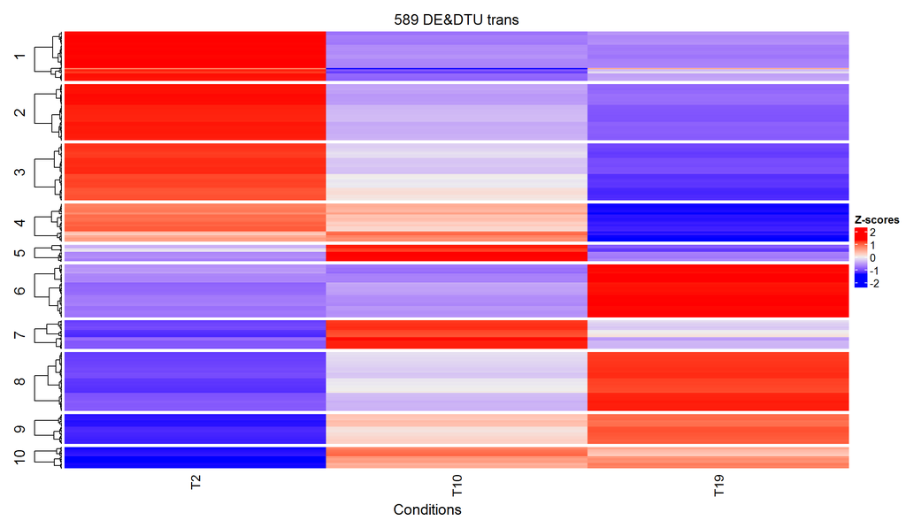

```r
################################################################################
##----->> DTU trans
dist.method <- 'euclidean'
cluster.method <- 'ward.D'
cluster.number <- 10
targets <- intersect(unique(DE_trans$target),unique(DTU_trans$target))
data2heatmap <- txi_trans$abundance[targets,]
column_title <- paste0(length(targets),' DE&DTU trans')
data2plot <- rowmean(x = t(data2heatmap),
                     group = samples$condition,
                     reorder = F)
data2plot <- t(scale(data2plot))

hc.dist <- dist(data2plot,method = dist.method)
hc <- fastcluster::hclust(hc.dist,method = cluster.method)
clusters <- cutree(hc, k = cluster.number)
clusters <- reorder.clusters(clusters = clusters,dat = data2plot)

g <- Heatmap(as.matrix(data2plot), name = 'Z-scores',
             cluster_rows = TRUE,
             clustering_method_rows=cluster.method,
             row_dend_reorder = T,
             show_row_names = FALSE,
             show_column_names = ifelse(ncol(data2plot)>10,F,T),
             cluster_columns = FALSE,
             split=clusters,
             column_title= column_title)

draw(g,column_title='Conditions',column_title_side = "bottom")
```

### Profile plot

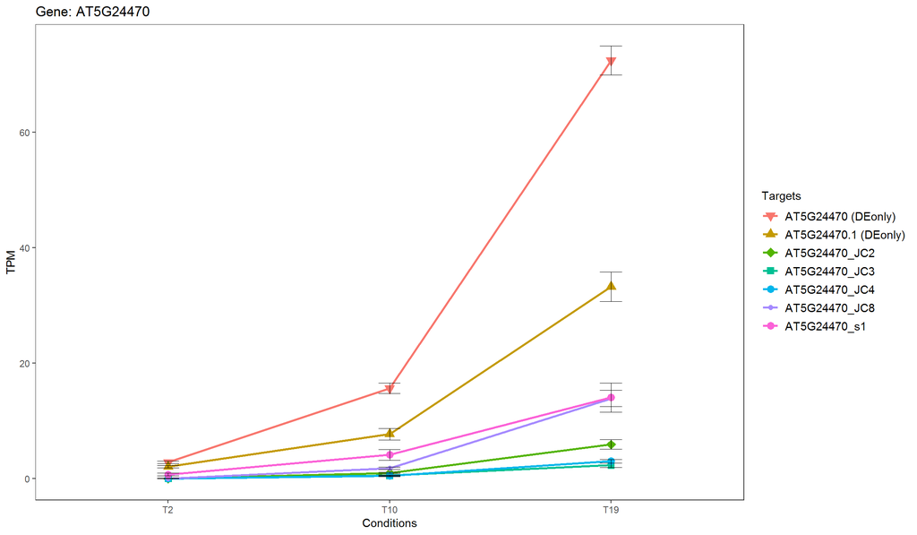

```r
################################################################################
##----->> generate annotation of DE and/or DAS, DE and/or DTU
DE.genes <- unique(DE_genes$target)
DAS.genes <- unique(DAS_genes$target)
DE.trans <- unique(DE_trans$target)
DTU.trans <- unique(DTU_trans$target)

genes.ann <- set2(DE.genes,DAS.genes)
names(genes.ann) <- c('DEonly','DE&DAS','DASonly')
genes.ann <- plyr::ldply(genes.ann,cbind)[,c(2,1)]
colnames(genes.ann) <- c('target','annotation')


trans.ann <- set2(DE.trans,DTU.trans)
names(trans.ann) <- c('DEonly','DE&DTU','DTUonly')
trans.ann <- plyr::ldply(trans.ann,cbind)[,c(2,1)]
colnames(trans.ann) <- c('target','annotation')

################################################################################
##give a gene name
gene <- 'AT5G24470'
##----->> profile plot of TPM or read counts
g.pr <- plot.abundance(data.exp = txi_trans$abundance[target_high$trans_high,],
                       gene = gene,
                       mapping = mapping[target_high$trans_high,],
                       genes.ann = genes.ann,
                       trans.ann = trans.ann,
                       trans.expressed = NULL,
                       reps = samples$condition,
                       y.lab = 'TPM')
g.pr
```

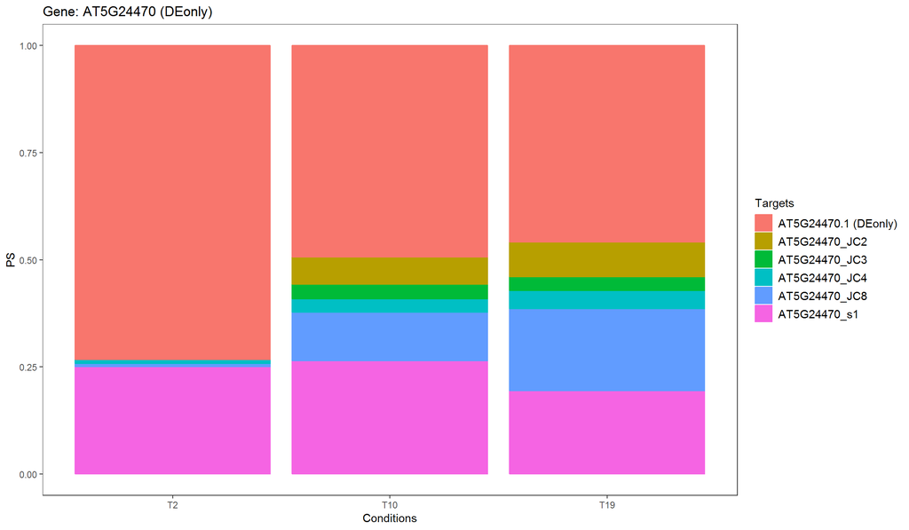

```r
################################################################################
##----->> PS plot
g.ps <- plot.PS(data.exp = txi_trans$abundance[target_high$trans_high,],
                gene = gene,
                mapping = mapping[target_high$trans_high,],
                genes.ann = genes.ann,
                trans.ann = trans.ann,
                trans.expressed = NULL,
                reps = samples$condition,
                y.lab = 'PS')
g.ps
```

### GO annotation plot of DE/DAS genes

To make the plot, users must provide GO annotation table in csv file, with first column of “Category” (i.e. CC, BP and MF), second column of GO “Term” and the remaining columns of statistics of significance.

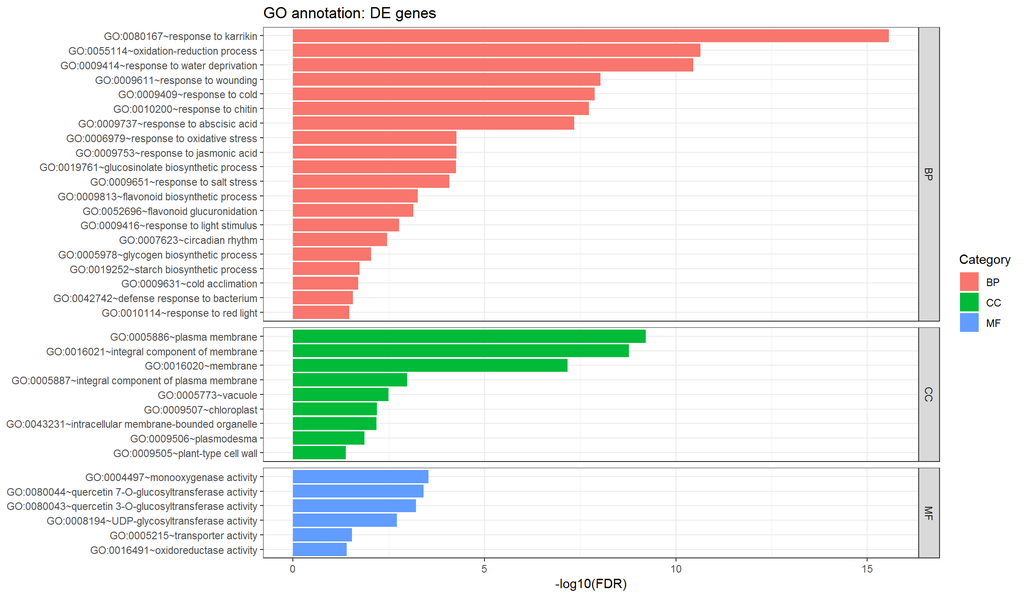

```r
################################################################################
##----->> DE genes
go.table <- suppressMessages(readr::read_csv(paste0(input.folder,'/DE genes GO terms.csv')))
go.table <- go.table[,c(1,2,5)]
plotGO(go.table = go.table,col.idx = '-log10(FDR)',
       plot.title = 'GO annotation: DE genes')
```

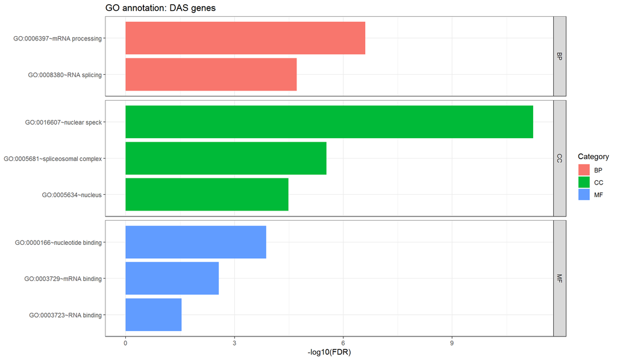

```r
################################################################################
##----->> DAS genes
go.table <- suppressMessages(readr::read_csv(paste0(input.folder,'/DAS genes GO terms.csv')))
go.table <- go.table[,c(1,2,5)]
plotGO(go.table = go.table,col.idx = '-log10(FDR)',
       plot.title = 'GO annotation: DAS genes')
```